# Tree splitting rules

Joshua Loftus

## Sorting preliminaries

Check the documentation for `?sort` and `?order` and then write code to output the values of `Y` sorted according to the order of `X`

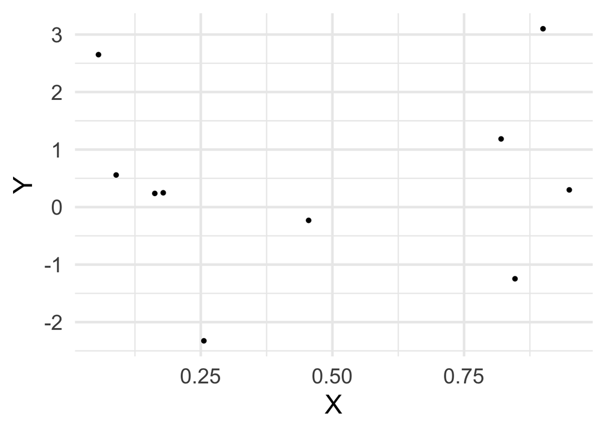

```r
X <- runif(10)
Y <- X + rnorm(10)
qplot(X, Y)
```

Base R solution

#### Check with tidyverse solution

```r
egdf <- data.frame(X = X, Y = Y)
egdf %>%
  arrange(X)
```

```
##             X          Y
## 1  0.05571544  2.6500709
## 2  0.08926600  0.5578119
## 3  0.16266617  0.2374518
## 4  0.17869520  0.2483979
## 5  0.25586316 -2.3250955
## 6  0.45478863 -0.2310837
## 7  0.82033903  1.1852317
## 8  0.84673601 -1.2461330
## 9  0.89994850  3.1002198
## 10 0.94981537  0.2989222
```

## Within-leaf averages

Below is some code that computes the average values of `Y` above and below a given split point

Base R

```r
x_split <- 0.5
c(mean(Y[X <= x_split]),
  mean(Y[X > x_split]))
```

```
## [1] 0.1895922 0.8345602
```

tidyverse

```r
egdf %>%
  group_by(X <= x_split) %>%
  summarize(avg_Y = mean(Y))
```

```
## # A tibble: 2 x 2
##   `X <= x_split` avg_Y
##   <lgl>          <dbl>
## 1 FALSE          0.835
## 2 TRUE           0.190
```

#### How much computation is required if we change the value of `x_split`?

#### Write code that sorts the data on `X` only once, and then, taking each `X` value as a split point consecutively, computes the average `Y` values above and below that split point while minimizing unnecessary computation

#### How can we use this to decide the split point for a regression tree?

#### How could we change this code to guarantee a minimum number of observations in each leaf?

## Numeric predictor

Write a function that inputs a single numeric predictor and outcome, and outputs a splitting point that achieves the lowest RSS

### Example data

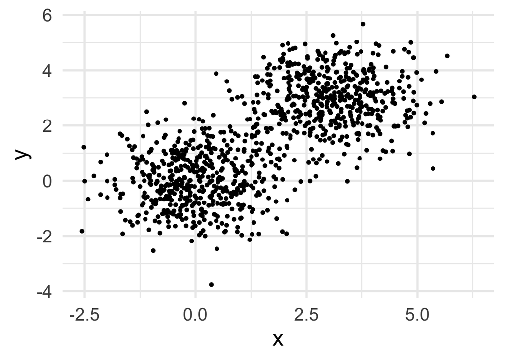

```r
n <- 1000
mixture_ids <- rbinom(n, 1, .5)
x <- rnorm(n) + 3*mixture_ids
y <- rnorm(n) + 3*mixture_ids
qplot(x,y)
```

#### Apply your function to the example data. Try different values of minimum observations per leaf

#### Change the data generating process to make the example easier/harder and repeat the above initial split

#### Compare the initial tree split to a Bayes decision boundary in one of the above examples. Increase `n` and repeat

#### Test the function on some `gapminder` data, plot the initial split point

## Multiple splits

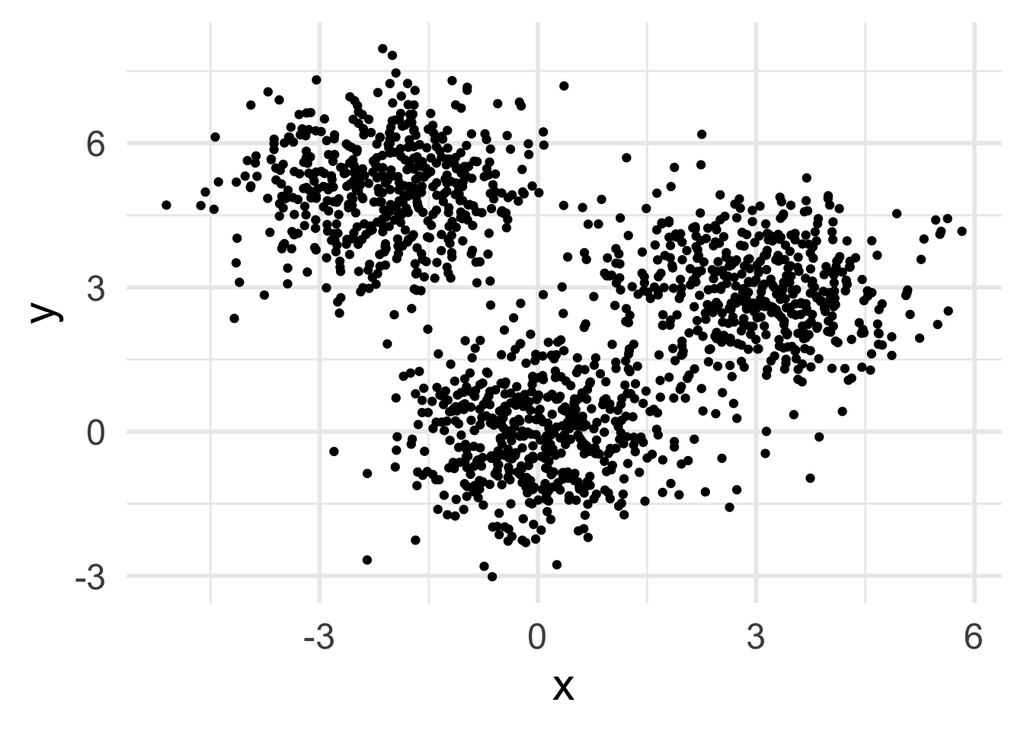

```r
n <- 1000
mixture_ids <- rbinom(n, 1, .5)
x <- rnorm(n) + 3*mixture_ids
y <- rnorm(n) + 3*mixture_ids
x <- c(x, rnorm(n/2, mean = -2))
y <- c(y, rnorm(n/2, mean = 5))
egdf <- data.frame(x = x, y = y)
egplot <- egdf %>%
  ggplot(aes(x, y)) +
  geom_point()
egplot
```

#### Use your single split function once, then split the data and apply the function again on each subset

#### Plot the data and each split point

# Extra practice

## Recursive splits

#### Write a function taking data and a maximum number of splits as inputs, and outputting a decision tree

#### How does computation scale in number of levels (tree depth)?

## Categorical predictors

#### Write a function for when the outcome variable is categorical and some splitting rule based on e.g. Gini index or entropy